# Gill_MDA_analysis

Samuel Gurr

2023-10-04

- Last updates: October 04, 2023

# OA Reexposure Challenge

## Load Libraries

```r
# library(lmtest) # to receive p value from betareg model
# library(FSA) # for the Dun test post hoc for SRH non-parametric 2 way anova]
# library(emmeans)
library(ggplot2)
library(dplyr)
library(tidyverse)
library(car)
# library(lmerTest)
library(tidyr)
# library(reshape2)
library(ggpubr)
# library(nlme)
# library(rcompanion) # to run the Schrier -Ray-Hare non parametric 2 way
library(ggpmisc) # stat_poly for inserting equation and R2 for ggplot line
knitr::opts_knit$set(root.dir = "C:/Users/samjg/Documents/Github_repositories/Airradians_CellularMolecular_OA/RAnalysis") # sets the working directory for the entire R markdown file - no need to reload the wd
```

## Load MDA assay raw data

- keep all data in raw form, merge here to a master raw
- output the raw master to the Data folder

```r
# WITHOUT PATH CORRECTION :::::::::::::::::::::::::::::::::::::::::::::::::::::::::::::::::::::::::::::::

# Ran on 202031004 - Plate 1
raw_1004_plate1      <- read.csv(file="Data/Colorimetric_assays/MDA/Runs_20231004/Plate1/Plate1_MDA_assay_nopathcorrection.csv",
                          sep = ",",
                          skip=2,
                          header=TRUE,
                          fileEncoding="latin1")
raw_1004_plate1_mtx  <- as.matrix(raw_1004_plate1[c(1:8),c(3:14)])
colnames(raw_1004_plate1_mtx) = c("1","2","3","4","5","6","7","8","9","10","11","12")
rownames(raw_1004_plate1_mtx) = c("A","B","C","D","E","F","G","H")
raw_1004_plate1_table <- as.data.frame.table(raw_1004_plate1_mtx, responseName = "value") %>%
                            dplyr::rename(well_row=Var1, well_column=Var2, Abs_695nm_no_path_correct=value) %>%
                            dplyr::mutate(well=paste0(well_row,well_column),
                                          Run_date ="20231004",
                                          Plate="1") %>%
                            dplyr::select(-c(well_row,well_column))

# Ran on 20230828 - Plate 2
raw_1004_plate2      <- read.csv(file="Data/Colorimetric_assays/MDA/Runs_20231004/Plate2/Plate2_MDA_assay_nopathcorrection.csv",
                          sep = ",",
                          skip=2,
                          header=TRUE,
                          fileEncoding="latin1")
raw_1004_plate2_mtx  <- as.matrix(raw_1004_plate2[c(1:8),c(3:14)])
colnames(raw_1004_plate2_mtx) = c("1","2","3","4","5","6","7","8","9","10","11","12")
rownames(raw_1004_plate2_mtx) = c("A","B","C","D","E","F","G","H")
raw_1004_plate2_table <- as.data.frame.table(raw_1004_plate2_mtx, responseName = "value") %>%
                            dplyr::rename(well_row=Var1, well_column=Var2, Abs_695nm_no_path_correct=value) %>%
                            dplyr::mutate(well=paste0(well_row,well_column),
                                          Run_date ="20231004",
                                          Plate="2") %>%
                            dplyr::select(-c(well_row,well_column))


# CUVETTE REFERENCE PATH CORRECTION  :::::::::::::::::::::::::::::::::::::::::::::::::::::::::::::::::::::::::::::::

# Ran on 202031004 - Plate 1
raw_1004_plate1_cuv      <- read.csv(file="Data/Colorimetric_assays/MDA/Runs_20231004/Plate1/Plate1_MDA_assay_cuvette_ref.csv",
                          sep = ",",
                          skip=2,
                          header=TRUE,
                          fileEncoding="latin1")
raw_1004_plate1_cuv_mtx  <- as.matrix(raw_1004_plate1_cuv[c(1:8),c(3:14)])
colnames(raw_1004_plate1_cuv_mtx) = c("1","2","3","4","5","6","7","8","9","10","11","12")
rownames(raw_1004_plate1_cuv_mtx) = c("A","B","C","D","E","F","G","H")
raw_1004_plate1_cuv_table <- as.data.frame.table(raw_1004_plate1_cuv_mtx, responseName = "value") %>%
                            dplyr::rename(well_row=Var1, well_column=Var2, Abs_695nm_cov_ref_correct=value) %>%
                            dplyr::mutate(well=paste0(well_row,well_column),
                                          Run_date ="20231004",
                                          Plate="1") %>%
                            dplyr::mutate(Abs_695nm_cov_ref_correct =
                                   case_when(Abs_695nm_cov_ref_correct == "Path?" ~ NA, # Path? replace as NA
                                             TRUE ~ as.numeric(Abs_695nm_cov_ref_correct) ) ) %>% # print if not Path?
                            dplyr::select(-c(well_row,well_column))
# Ran on 20230828 - Plate 2
raw_1004_plate2_cuv      <- read.csv(file="Data/Colorimetric_assays/MDA/Runs_20231004/Plate2/Plate2_MDA_assay_cuvette_ref.csv",
                          sep = ",",
                          skip=2,
                          header=TRUE,
                          fileEncoding="latin1")
raw_1004_plate2_cuv_mtx  <- as.matrix(raw_1004_plate2_cuv[c(1:8),c(3:14)])
colnames(raw_1004_plate2_cuv_mtx) = c("1","2","3","4","5","6","7","8","9","10","11","12")
rownames(raw_1004_plate2_cuv_mtx) = c("A","B","C","D","E","F","G","H")
raw_1004_plate2_cuv_table <- as.data.frame.table(raw_1004_plate2_cuv_mtx, responseName = "value") %>%
                            dplyr::rename(well_row=Var1, well_column=Var2, Abs_695nm_cov_ref_correct=value) %>%
                            dplyr::mutate(well=paste0(well_row,well_column),
                                          Run_date ="20231004",
                                          Plate="2") %>%
                            dplyr::mutate(Abs_695nm_cov_ref_correct =
                                   case_when(Abs_695nm_cov_ref_correct == "Path?" ~ NA, # Path? replace as NA
                                             TRUE ~ as.numeric(Abs_695nm_cov_ref_correct) ) ) %>% # print if not Path?
                            dplyr::select(-c(well_row,well_column))
# INTERNAL WATER CONSTANT PATH CORRECTION  :::::::::::::::::::::::::::::::::::::::::::::::::::::::::::::::::::::::::::::::

# Ran on 202031004 - Plate 1
raw_1004_plate1_water  <- read.csv(file="Data/Colorimetric_assays/MDA/Runs_20231004/Plate1/Plate1_MDA_assay_water_constant.csv",
                          sep = ",",
                          skip=1,
                          header=TRUE,
                          fileEncoding="latin1")
raw_1004_plate1_water_mtx  <- as.matrix(raw_1004_plate1_water[c(1:8),c(3:14)])
colnames(raw_1004_plate1_water_mtx) = c("1","2","3","4","5","6","7","8","9","10","11","12")
rownames(raw_1004_plate1_water_mtx) = c("A","B","C","D","E","F","G","H")
raw_1004_plate1_water_table <- as.data.frame.table(raw_1004_plate1_water_mtx, responseName = "value") %>%
                            dplyr::rename(well_row=Var1, well_column=Var2, Abs_695nm_water_constant_correct=value) %>%
                            dplyr::mutate(well=paste0(well_row,well_column),
                                          Run_date ="20231004",
                                          Plate="1") %>%
                            dplyr::mutate(Abs_695nm_water_constant_correct =
                                   case_when(Abs_695nm_water_constant_correct == "Path?" ~ NA, # Path? replace as NA
                                             TRUE ~ as.numeric(Abs_695nm_water_constant_correct) ) ) %>% # print if not Path?
                            dplyr::select(-c(well_row,well_column))
# Ran on 20230828 - Plate 2
raw_1004_plate2_water  <- read.csv(file="Data/Colorimetric_assays/MDA/Runs_20231004/Plate2/Plate2_MDA_assay_water_constant.csv",
                          sep = ",",
                          skip=2,
                          header=TRUE,
                          fileEncoding="latin1")
raw_1004_plate2_water_mtx  <- as.matrix(raw_1004_plate2_water[c(1:8),c(3:14)])
colnames(raw_1004_plate2_water_mtx) = c("1","2","3","4","5","6","7","8","9","10","11","12")
rownames(raw_1004_plate2_water_mtx) = c("A","B","C","D","E","F","G","H")
raw_1004_plate2_water_table <- as.data.frame.table(raw_1004_plate2_water_mtx, responseName = "value") %>%
                            dplyr::rename(well_row=Var1, well_column=Var2, Abs_695nm_water_constant_correct=value) %>%
                            dplyr::mutate(well=paste0(well_row,well_column),
                                          Run_date ="20231004",
                                          Plate="2") %>%
                            dplyr::mutate(Abs_695nm_water_constant_correct =
                                   case_when(Abs_695nm_water_constant_correct == "Path?" ~ NA, # Path? replace as NA
                                             TRUE ~ as.numeric(Abs_695nm_water_constant_correct) ) ) %>% # print if not Path?
                            dplyr::select(-c(well_row,well_column))
# MERGE WITHIN PLATE


raw_Plate1_MDA <-  merge(raw_1004_plate1_table,
                        (merge(raw_1004_plate1_cuv_table,raw_1004_plate1_water_table)) )

raw_Plate2_MDA <-  merge(raw_1004_plate2_table,
                        (merge(raw_1004_plate2_cuv_table,raw_1004_plate2_water_table)) )

# load metadata
metadata      <- read.csv(file="Data/Colorimetric_assays/MDA/Metadata_MDA.csv",
                          sep = ",",
                          header=TRUE)

# merge the rbind of all raw data with the metadat
raw_MDA_master <- merge( (rbind(raw_Plate1_MDA,raw_Plate2_MDA)),
                         (metadata %>% dplyr::select(!Notes)) )
nrow(raw_MDA_master) # 192
```

```
[1] 192
```

```r
# View(raw_MDA_master) # view it if you want to
```

## MDA raw plots

- any glaring outliers?

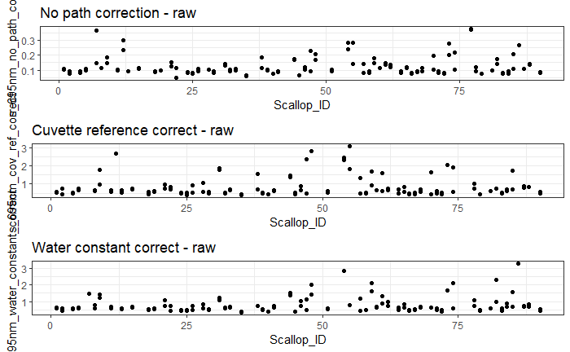

```r
# plot the data to see any glaring outliers
raw_plot_no_cor <- raw_MDA_master %>%
                      dplyr::filter(Type %in% 'Sample') %>%
                      ggplot(aes(y = Abs_695nm_no_path_correct,
                                 x  = Scallop_ID)) +
                      theme_bw() +
                      ggtitle("No path correction - raw") +
                      geom_point()

raw_plot_cuvette_cor <- raw_MDA_master %>%
                      dplyr::filter(Type %in% 'Sample') %>%
                      ggplot(aes(y = Abs_695nm_cov_ref_correct,
                                 x  = Scallop_ID)) +
                      theme_bw() +
                      ggtitle("Cuvette reference correct - raw") +
                      geom_point()


raw_plot_water_cor <- raw_MDA_master %>%
                      dplyr::filter(Type %in% 'Sample') %>%
                      ggplot(aes(y = Abs_695nm_water_constant_correct,
                                 x  = Scallop_ID)) +
                      theme_bw() +
                      ggtitle("Water constant correct - raw") +
                      geom_point()
ggarrange(raw_plot_no_cor,
          raw_plot_cuvette_cor,
          raw_plot_water_cor,
          nrow=3)
```

```r
# write csv
write.csv(raw_MDA_master, file = "Data/Colorimetric_assays/MDA/Raw_Master_MDA.csv")


raw_MDA_master %>% dplyr::filter((Scallop_ID == 73))
```

| well | Run_date | Plate | Abs_695nm_no_path_correct | Abs_695nm_cov_ref_correct | Abs_695nm_water_constant_correct | Type | Scallop_ID |
| --- | --- | --- | --- | --- | --- | --- | --- |
| A11 | 20231004 | 1 | 0.2041 | 2.04794 | 1.684579 | Sample | 73 |
| A12 | 20231004 | 1 | 0.2768 | NA | NA | Sample | 73 |

## Load BCA assay raw data

- keep all data in raw form, merge here to a master raw
- output the raw master to the Data folder

```r
# Ran on 20231004 - Plate 1
BCA_1004_plate1      <- read.csv(file="Data/Colorimetric_assays/BCA_MDAcorrection/Runs_20231004/Plate1/Plate1_BCA_MDAcorrection.csv",
                          sep = ",",
                          skip=2,
                          header=TRUE,
                          fileEncoding="latin1")
BCA_1004_plate1_mtx  <- as.matrix(BCA_1004_plate1[c(1:8),c(3:14)])
colnames(BCA_1004_plate1_mtx) = c("1","2","3","4","5","6","7","8","9","10","11","12")
rownames(BCA_1004_plate1_mtx) = c("A","B","C","D","E","F","G","H")
BCA_1004_plate1_table <- as.data.frame.table(BCA_1004_plate1_mtx, responseName = "value") %>%
                            dplyr::rename(well_row=Var1, well_column=Var2, Abs_562nm=value) %>%
                            dplyr::mutate(well=paste0(well_row,well_column),
                                          Run_date ="20231004",
                                          Plate="1") %>%
                            dplyr::select(-c(well_row,well_column))

# Ran on 20231004 - Plate 2
BCA_1004_plate2      <- read.csv(file="Data/Colorimetric_assays/BCA_MDAcorrection/Runs_20231004/Plate2/Plate2_BCA_MDAcorrection.csv",
                          sep = ",",
                          skip=2,
                          header=TRUE,
                          fileEncoding="latin1")
BCA_1004_plate2_mtx  <- as.matrix(BCA_1004_plate2[c(1:8),c(3:14)])
colnames(BCA_1004_plate2_mtx) = c("1","2","3","4","5","6","7","8","9","10","11","12")
rownames(BCA_1004_plate2_mtx) = c("A","B","C","D","E","F","G","H")
BCA_1004_plate2_table <- as.data.frame.table(BCA_1004_plate2_mtx, responseName = "value") %>%
                            dplyr::rename(well_row=Var1, well_column=Var2, Abs_562nm=value) %>%
                            dplyr::mutate(well=paste0(well_row,well_column),
                                          Run_date ="20231004",
                                          Plate="2") %>%
                            dplyr::select(-c(well_row,well_column))

# load metadata

metadata_BCA <- read.csv(file="Data/Colorimetric_assays/BCA_MDAcorrection/Metadata_BCA_MDAcorrection.csv",
                          sep = ",",
                          header=TRUE)

# merge the rbind of all raw data with the metadat
raw_BCA_master <- merge( (rbind(BCA_1004_plate1_table,
                         BCA_1004_plate2_table)),
                  metadata_BCA)
# View(raw_BCA_om)

# write csv
write.csv(raw_BCA_master, file = "Data/Colorimetric_assays/BCA_MDAcorrection/Raw_Master_BCA_MDAcorrection.csv")
```

## BCA raw plots

- any glaring outliers?

```r
# plot the data to see any glaring outliers
raw_plot <- raw_BCA_master %>%
                      dplyr::filter(Type %in% 'Sample') %>%
                      ggplot(aes(y = Abs_562nm,
                                 x  = Scallop_ID)) +
                      theme_bw() +
                      ggtitle("BCA -raw") +
                      geom_point()

raw_plot
```

[output not shown]

- Load Experiment metadata - merge with the loaded raw colorimetric data

```r
Exp_metadata      <- read.csv(file="Data/Experiment_metadata.csv",sep = ",",header=TRUE)
```

# Finalize BCA data

- Objs:
  - 1. Merge by the common ‘Scallop_ID’ and retain all rows in the colorimetric data (all=T)
  - Why? We unfortunately found that that the dewar was not properly unloaded on day 14 of the experiment, below we can reveal replicates that were lost (hence ‘NAs’ via merge below)
  - 2. omit NAs - empty wells (no sample or standard)
  - 3. separate standards from samples
  - 4. Run standard curve, calculate totalprotein
  - 5. Calculate total protien; subtract out background + correct for standard curve + average

```r
raw_BCA <- read.csv(file = "Data/Colorimetric_assays/BCA_MDAcorrection/Raw_Master_BCA_MDAcorrection.csv", head = T) # the raw_BCA_om file

# * (1) Merge by the common 'Scallop_ID' and retain all rows in the colorimetric data (all=T)
# - Why? We unfortunately found that that the dewar was not properly unloaded
# on day 14 of the experiment, below we can reveal replicates that were lost (hence 'NAs' via merge below)
raw_BCA_merged    <- merge(raw_BCA, Exp_metadata, by='Scallop_ID',all=TRUE)

# View(raw_BCA_merged)
lost_gill_samples <- raw_BCA_merged %>% dplyr::filter(Abs_562nm %in% NA)
nrow(lost_gill_samples) # 27 -NOTE: NOT ALL of these were lost, some due to low yield of supernatant to run,

# * (2) omit NAs - empty wells (no sample or standard)
raw_BCA_merged_om <- raw_BCA_merged %>% dplyr::filter(!Type %in% NA)

# View(raw_BCA_merged_om)

# * (3) separate standards from samples, format the standards
BCA_standards <- raw_BCA_merged_om %>%
                    dplyr::filter(grepl('Standard', Type)) %>% # grepl for 'contains' string
                    dplyr::mutate(BCA_ug_mL =
                                    as.numeric(gsub('.*_','',Type))) %>% # (i.e. 25 in 'Standards_25')
                    dplyr::mutate(Unique_ID = paste0('Plate_',Plate,'_', Type))



# * (4) Run standard curve, calculate totalprotein
BCA_background_zero <- BCA_standards %>%
                        dplyr::filter(Type %in% 'Standard_0') %>%
                        dplyr::filter(Abs_562nm < 0.1) %>% # one outlier of 0.4150 -omit that here
                        dplyr::select(Unique_ID,Plate, BCA_ug_mL,Abs_562nm) %>% # select columns of interest
                        dplyr::group_by(Unique_ID, Plate, BCA_ug_mL) %>% # group by to get the means
                        dplyr::summarise_each(funs(mean,sd,se=sd(.)/sqrt(n()))) # get all the stats
# Plate_1 blank to correct ==   0.0821
# Plate_2 blank to correct == 0.0831

# correct standards (subtract out the blank) and average
BCA_standards_means <- BCA_standards %>%
                        #dplyr::filter(!Type %in% 'Standard_0') %>%
                        dplyr::mutate(Abs_562nm_cor =
                                     case_when(Plate == 1 ~ (Abs_562nm-0.0821),
                                               Plate == 2 ~ (Abs_562nm-0.0831) ) ) %>%
                        dplyr::select(Unique_ID, Plate, BCA_ug_mL, Abs_562nm_cor) %>% # select columns
                        dplyr::group_by(Unique_ID, Plate, BCA_ug_mL) %>% # group by to get the means
                        dplyr::summarise_each(funs(mean,sd,se=sd(.)/sqrt(n()))) # get all the stats

# quadratic standard curve
BCA_stand_plots_quadratic <- BCA_standards_means %>% # QUADRATIC SMOOTH LINE WORKS BEST HERE (MANUFACTURERS INSTRUCTIONS)
                     #dplyr::filter(!BCA_ug_mL %in% 25) %>% # hash me out to test
                     ggplot(aes(y=mean, x=BCA_ug_mL)) +
                        geom_point() +
                        theme_bw() +
                        labs(y= "Net Absorbance at 562nm", x = "Protein Concentration in ug/mL") +
                        #geom_line() +
                        #stat_poly_line(color='red') +
                        #geom_smooth() +
                        stat_smooth(method = "lm", formula = y ~ x + I(x^2), size = 1) +
                        stat_poly_eq(parse=T, aes(label = ..eq.label..), formula=y ~ x + I(x^2)) +
                        ggtitle('Quadratic') +
                        #stat_poly_eq(use_label(c("eq", "R2"))) +
                        facet_wrap(~Plate)

# Linear standards based on the last few - this is important if we have high unknowns resulting in negative descriminant
BCA_stand_plots_linear <- BCA_standards_means %>% # QUADRATIC SMOOTH LINE WORKS BEST HERE (MANUFACTURERS INSTRUCTIONS)
                     dplyr::filter(!BCA_ug_mL %in% c('0','25','125')) %>% # hash me out to test
                     ggplot(aes(y=mean, x=BCA_ug_mL)) +
                        geom_point() +
                        theme_bw() +
                        labs(y= "Net Absorbance at 562nm", x = "Protein Concentration in ug/mL") +
                        #geom_line() +
                        #stat_poly_line(color='red') +
                        #geom_smooth() +
                        stat_smooth(method = "lm", formula = y ~ x, size = 1) +
                        stat_poly_eq(parse=T, aes(label = ..eq.label..), formula=y ~ x) +
                        ggtitle('Linear - for negative desriminant') +
                        #stat_poly_eq(use_label(c("eq", "R2"))) +
                        facet_wrap(~Plate)

#print these standard figures
pdf(paste("Output/Colorimetric_assays/BCA_MDAcorrection/Standard_Curve_BCA_MDAcorrection.pdf", sep =''),
    width=10,
    height=7)
print(ggarrange(BCA_stand_plots_quadratic,BCA_stand_plots_linear))
dev.off()

# Note: plates 1 and 2 were completed in quick succession, loaded at the same time with a ~5 minute lag between  them
# strangely, the standard curve for plate 1 is much different, suggesting possible error?
# BCA completed for ATP correction found very similar quadratic EQs to the plate 2, we will move forward with ONE
# curve EQ for all unknowns (plate 2)

# Standard curve, Plate 2 equation y = 0.045 + 0.00125x - 1.3x10^-7x^2 - need to solve for x!

# * (5) Calculate Total protein per sample; subtract out background + correct for standard curve +  average

# Remember!.. from above we have the following blanks to correct unknowns
# Plate_1 blank to correct ==   0.0821
# Plate_2 blank to correct == 0.0831

# Quadratic Standard curve, Plate 2 (use for plate 1 also!)
a <- -1.2*10^-7
b <- 0.00125
c <- 0.045
# EQ: (-(b1) + sqrt( (b1^2) - (4*(((a1)-Abs_562nm_cor))*(c1)) ))/(2*a1)

# Linear Standard curve, Plate 2 (use in case of neg discrim, high values undetermined via quadratic
slope = 0.00108
yint  = 0.143

# IMPORTANT! we used 25 ul of the standards and 25 ul of the unknowns (samples)
# therefore we can interpret the unknown direct to the the standard curve without having
# to account for addition factors, fot example, if we used 5 ul unknown (sample) we would have to adjust
# by multiplying by 5 to reach the standard curve

V = 0.025 # 25 ul or 0.025 mL

TotalProtein_final <- raw_BCA_merged_om %>%
                      dplyr::filter(Type %in% 'Sample') %>% # call samples
                      dplyr::mutate(Unique_ID =
                                      paste0('Plate_',Plate,'_', Scallop_ID)) %>% # unique ID t0 group by
                      dplyr::mutate(Abs_562nm_cor = # correct the raw abs, subtract background
                                   case_when(Plate == 1 ~ (Abs_562nm-0.0821), # for plate 1
                                             Plate == 2 ~ (Abs_562nm-0.0831) ) ) %>% # for plate 2
                      dplyr::mutate(TotalProtein_ug_mL =
                                      case_when(
                                        # case when abs > 3.3, use the plate 2 linear model to extrapolate
                                        Abs_562nm_cor > 3.3 ~ ((Abs_562nm-yint)/slope),
                                        # else, run plate 2 quadratic
                                        TRUE ~ ((-(b) + sqrt( (b^2) - (4*a*(c-Abs_562nm_cor)) ) ) / (2*a))),
                                    # convert ug per mL concentration to ug in 25 ul sample
                                    TotalProtein_ug = TotalProtein_ug_mL*V) %>%
                      dplyr::group_by(Day,pCO2_history,pCO2_exposure,
                                      Unique_ID, Plate, Scallop_ID) %>% # group by to get the means
                      dplyr::summarise(mean_TotalProtein_ug = mean(TotalProtein_ug),
                                       sd_TotalProtein_ug   = sd(TotalProtein_ug),
                                       n = n(),
                                       se_TotalProtein_ug  = sd_TotalProtein_ug / sqrt(n))

# View(TotalProtein_final)
nrow(TotalProtein_final) # 65


# write csv
write.csv(TotalProtein_final, file = "Output/Colorimetric_assays/BCA_MDAcorrection/Calc_Master_BCA_MDAcorrection.csv")
```

# Finalize MDA data

- Objs:
  - 1. Merge by the common ‘Scallop_ID’ and retain all rows in the colorimetric data (all=T)
  - Why? We unfortunately found that that the dewar was not properly unloaded on day 14 of the experiment, below we can reveal replicates that were lost (hence ‘NAs’ via merge below)
  - 2. omit NAs - empty wells (no sample or standard)
  - 3. separate standards from samples
  - 4. Run standard curve, calculate totalprotein
  - 5. Calculate MDA; subtract out background + correct for standard curve + average +

| Scallop_ID | X | well | Run_date | Plate | Abs_695nm_no_path_correct | Abs_695nm_cov_ref_correct | Abs_695nm_water_constant_correct | Type | Date | Day | pCO2_history | pCO2_exposure |
| --- | --- | --- | --- | --- | --- | --- | --- | --- | --- | --- | --- | --- |
| 1 | 173 | H11 | 20231004 | 1 | 0.1070 | 0.553521 | 0.607771 | Sample | 20230502 | 1 | low | low |
| 1 | 175 | H12 | 20231004 | 1 | 0.1025 | 0.519815 | 0.631647 | Sample | 20230502 | 1 | low | low |
| 2 | 117 | E8 | 20231004 | 1 | 0.0948 | 0.763908 | 0.602992 | Sample | 20230516 | 14 | low | low |
| 2 | 115 | E7 | 20231004 | 1 | 0.0751 | 0.430577 | 0.425763 | Sample | 20230516 | 14 | low | low |
| 4 | 84 | D3 | 20231004 | 2 | 0.0952 | 0.507949 | 0.568967 | Sample | 20230502 | 1 | low | low |
| 4 | 86 | D4 | 20231004 | 2 | 0.0820 | 0.469975 | 0.527761 | Sample | 20230502 | 1 | low | low |
| 5 | 90 | D6 | 20231004 | 2 | 0.1087 | 0.765259 | 0.654030 | Sample | 20230516 | 14 | low | low |
| 5 | 88 | D5 | 20231004 | 2 | 0.0961 | 0.664039 | 0.594691 | Sample | 20230516 | 14 | low | low |
| 7 | 134 | F4 | 20231004 | 2 | 0.1479 | NA | 1.478805 | Sample | 20230502 | 1 | low | low |
| 7 | 132 | F3 | 20231004 | 2 | 0.3667 | NA | NA | Sample | 20230502 | 1 | low | low |

[output cut: 146 more lines]

Finally we are here… the moment of truth!

# MERGE MDA WITH TOTAL PROTEIN DATA

| Group.1 | Group.2 | Group.3 | x |
| --- | --- | --- | --- |
| 1 | low | low | 56.85969 |
| 14 | low | low | 47.52539 |
| 1 | moderate | low | 45.97052 |
| 14 | moderate | low | 43.68067 |
| 1 | severe | low | 38.55728 |
| 14 | severe | low | 44.77904 |
| 1 | low | moderate | 50.01584 |
| 14 | low | moderate | 91.21534 |
| 1 | moderate | moderate | 45.34354 |
| 14 | moderate | moderate | 33.17222 |

[output cut: 8 more lines]

# FIGURES

| X | Day | pCO2_history | pCO2_exposure | Scallop_ID | mean_MDA_µmol | mean_TotalProtein_ug | MDA_µmol_µg_protein |
| --- | --- | --- | --- | --- | --- | --- | --- |
| 20 | 1 | moderate | low | 38 | 158.88099 | 8.575634 | 9.263513 |
| 66 | NA | NA | NA | NA | -20.33748 | -1.059688 | 9.595975 |

- MDA (NOT corrected)

[figure not shown]

[figure not shown]

```r
LowpCO2_MatchMismatch_RxnNorm <- MASTER_DF %>% # data %>%
  dplyr::filter(pCO2_history == 'low') %>% # filter for desired date of rhte experiment
  dplyr::mutate(MDA_µmol_µg_protein = as.numeric(MDA_µmol_µg_protein)) %>%
  dplyr::select(c('Day','pCO2_exposure','pCO2_history','MDA_µmol_µg_protein')) %>%
  na.omit() %>%
  dplyr::mutate(Match_Mismatch =
                  case_when(pCO2_exposure == 'low' ~ 'match',
                            TRUE ~ 'mismatch')) %>%
  # we have means (from x2 assay reps per individual), now mean by treatment!
  group_by(Day, Match_Mismatch) %>% # group by columns for treatment
  dplyr::summarise( # summarise to acquire the mean and SE for plotting
    MDA_mean = mean(MDA_µmol_µg_protein), # mean
    MDA_sd = sd(MDA_µmol_µg_protein), # sd
    MDA_n = n(), # count
    MDA_se = MDA_sd / sqrt(MDA_n)) %>% # SE
  # plot it
  ggplot(aes(x=as.factor(Day), y=MDA_mean, group=Match_Mismatch)) + # call the new mean
    geom_line(aes(group = factor(Match_Mismatch),
                  linetype = Match_Mismatch),
              size = 0.5,
              position=position_dodge(.4)) +  # connect a line between variables
    scale_linetype_manual(values=c("solid", "dashed")) +
    geom_point(aes(shape=Match_Mismatch, fill=Match_Mismatch), size = 4.5,position=position_dodge(.4)) +
    scale_shape_manual(values=c(21, 22, 24)) + # filled circle, filled triangle, and X
    scale_fill_manual(values=c("#009E73", "black")) + # fill circles
    geom_errorbar(aes(ymin=(MDA_mean)-(MDA_se), # new means and se by treatment
                      ymax=(MDA_mean)+(MDA_se)), # new means and se by treatment
                  width=0,position=position_dodge(.4)) + # width determines the length of the end ticks
    theme_classic() +
    theme(panel.grid.major = element_blank(), panel.grid.minor = element_blank(),legend.position = "none") +
    ggtitle("Low pCO2 history - Match v. mismatch") +
    # scale_y_continuous(expand = c(0, 0), limits = c(10, 40)) + # true 0 origin
    # scale_y_continuous(expand = c(0, 0), limits = c(0, 2.5)) + # true 0 origin
    labs(y= "MDA (umol ug protein-1)", x = "Time exposed (days)")

ModeratepCO2_MatchMismatch_RxnNorm <- MASTER_DF %>% # data %>%
  dplyr::filter(pCO2_history == 'moderate') %>% # filter for desired date of rhte experiment
  dplyr::mutate(MDA_µmol_µg_protein = as.numeric(MDA_µmol_µg_protein)) %>%
  dplyr::select(c('Day','pCO2_exposure','pCO2_history','MDA_µmol_µg_protein')) %>%
  na.omit() %>%
  dplyr::mutate(Match_Mismatch =
                  case_when(pCO2_exposure == 'moderate' ~ 'match',
                            TRUE ~ 'mismatch')) %>%
  # we have means (from x2 assay reps per individual), now mean by treatment!
  group_by(Day, Match_Mismatch) %>% # group by columns for treatment
  dplyr::summarise( # summarise to acquire the mean and SE for plotting
    MDA_mean = mean(MDA_µmol_µg_protein), # mean
    MDA_sd = sd(MDA_µmol_µg_protein), # sd
    MDA_n = n(), # count
    MDA_se = MDA_sd / sqrt(MDA_n)) %>% # SE
  # plot it
  ggplot(aes(x=as.factor(Day), y=MDA_mean, group=Match_Mismatch)) + # call the new mean
    geom_line(aes(group = factor(Match_Mismatch),
                  linetype = Match_Mismatch),
              size = 0.5,
              position=position_dodge(.4)) +  # connect a line between variables
    scale_linetype_manual(values=c("solid", "dashed")) +
    geom_point(aes(shape=Match_Mismatch, fill=Match_Mismatch), size = 4.5,position=position_dodge(.4)) +
    scale_shape_manual(values=c(21, 22, 24)) + # filled circle, filled triangle, and X
    scale_fill_manual(values=c("#E69F00", "black")) + # fill circles
    geom_errorbar(aes(ymin=(MDA_mean)-(MDA_se), # new means and se by treatment
                      ymax=(MDA_mean)+(MDA_se)), # new means and se by treatment
                  width=0,position=position_dodge(.4)) + # width determines the length of the end ticks
    theme_classic() +
    theme(panel.grid.major = element_blank(), panel.grid.minor = element_blank(),legend.position = "none") +
    ggtitle("Moderate pCO2 history - Match v. mismatch") +
    # scale_y_continuous(expand = c(0, 0), limits = c(10, 40)) + # true 0 origin
    # scale_y_continuous(expand = c(0, 0), limits = c(0, 2.5)) + # true 0 origin
    labs(y= "MDA (µmol ng protein-1)", x = "Time exposed (days)")


HighpCO2_MatchMismatch_RxnNorm <- MASTER_DF %>% # data %>%
  dplyr::filter(pCO2_history == 'severe') %>% # filter for desired date of rhte experiment
  dplyr::mutate(MDA_µmol_µg_protein = as.numeric(MDA_µmol_µg_protein)) %>%
  dplyr::select(c('Day','pCO2_exposure','pCO2_history','MDA_µmol_µg_protein')) %>%
  na.omit() %>%
  dplyr::mutate(Match_Mismatch =
                  case_when(pCO2_exposure == 'severe' ~ 'match',
                            TRUE ~ 'mismatch')) %>%
  # we have means (from x2 assay reps per individual), now mean by treatment!
  group_by(Day, Match_Mismatch) %>% # group by columns for treatment
  dplyr::summarise( # summarise to acquire the mean and SE for plotting
    MDA_mean = mean(MDA_µmol_µg_protein), # mean
    MDA_sd = sd(MDA_µmol_µg_protein), # sd
    MDA_n = n(), # count
    MDA_se = MDA_sd / sqrt(MDA_n)) %>% # SE
  # plot it
  ggplot(aes(x=as.factor(Day), y=MDA_mean, group=Match_Mismatch)) + # call the new mean
    geom_line(aes(group = factor(Match_Mismatch),
                  linetype = Match_Mismatch),
              size = 0.5,
              position=position_dodge(.4)) +  # connect a line between variables
    scale_linetype_manual(values=c("solid", "dashed")) +
    geom_point(aes(shape=Match_Mismatch, fill=Match_Mismatch), size = 4.5,position=position_dodge(.4)) +
    scale_shape_manual(values=c(21, 22, 24)) + # filled circle, filled triangle, and X
    scale_fill_manual(values=c("#CC79A7", "black")) + # fill circles
    geom_errorbar(aes(ymin=(MDA_mean)-(MDA_se), # new means and se by treatment
                      ymax=(MDA_mean)+(MDA_se)), # new means and se by treatment
                  width=0,position=position_dodge(.4)) + # width determines the length of the end ticks
    theme_classic() +
    theme(panel.grid.major = element_blank(), panel.grid.minor = element_blank(),legend.position = "none") +
    ggtitle("High pCO2 history - Match v. mismatch") +
    # scale_y_continuous(expand = c(0, 0), limits = c(10, 40)) + # true 0 origin
    # scale_y_continuous(expand = c(0, 0), limits = c(0, 2.5)) + # true 0 origin
    labs(y= "MDA (µmol ng protein-1)", x = "Time exposed (days)")

ggarrange(LowpCO2_MatchMismatch_RxnNorm,
          ModeratepCO2_MatchMismatch_RxnNorm,
          HighpCO2_MatchMismatch_RxnNorm,
          nrow=3)
```

- Total Protein

```r
MASTER_DF <- read.csv(file = "Output/Colorimetric_assays/ATP/ATP_Master.csv", head = T)


Day1_TotalProtein_RxnNorm <- MASTER_DF %>% # data %>%
  dplyr::filter(Day == 1) %>% # filter for desired date of rhte experiment
  dplyr::mutate(mean_TotalProtein_ng = as.numeric(mean_TotalProtein_ng)) %>%
  dplyr::select(c('Day','pCO2_exposure','pCO2_history','mean_TotalProtein_ng')) %>%
  na.omit() %>%
  # we have means (from x2 assay reps per individual), now mean by treatment!
  group_by(pCO2_exposure, pCO2_history) %>% # group by columns for treatment
  dplyr::summarise( # summarise to acquire the mean and SE for plotting
    TP_mean = mean(mean_TotalProtein_ng), # mean
    TP_sd = sd(mean_TotalProtein_ng), # sd
    TP_n = n(), # count
    TP_se = TP_sd / sqrt(TP_n)) %>% # SE
  # plot it
  ggplot(aes(x=pCO2_exposure, y=TP_mean, group=pCO2_history)) + # call the new mean
    geom_line(aes(group = factor(pCO2_history),
                  linetype = pCO2_history),
              size = 0.5,
              position=position_dodge(.4)) +  # connect a line between variables
    scale_linetype_manual(values=c("solid", "dashed", "dotted")) +
    geom_point(aes(shape=pCO2_history, fill=pCO2_history), size = 4.5,position=position_dodge(.4)) +
    scale_shape_manual(values=c(21, 22, 24)) + # filled circle, filled triangle, and X
    scale_fill_manual(values=c("#009E73","#E69F00", "#CC79A7")) + # fill circles
    geom_errorbar(aes(ymin=(TP_mean)-(TP_se), # new means and se by treatment
                      ymax=(TP_mean)+(TP_se)), # new means and se by treatment
                  width=0,position=position_dodge(.4)) + # width determines the length of the end ticks
    theme_classic() +
    theme(panel.grid.major = element_blank(), panel.grid.minor = element_blank(),legend.position = "none") +
    # scale_y_continuous(expand = c(0, 0), limits = c(0, 3)) + # true 0 origin
    scale_y_continuous(expand = c(0, 0), limits = c(0, 0.15)) + # true 0 origin
    ggtitle("Total Protein, Day 1") +
    labs(y= "Total Protie (ng mL)", x = "Days")
# Day1_TotalProtein_RxnNorm # view the plot


Day14_TotalProtein_RxnNorm <- MASTER_DF %>% # data %>%
  dplyr::filter(Day == 14) %>% # filter for desired date of rhte experiment
  dplyr::mutate(mean_TotalProtein_ng = as.numeric(mean_TotalProtein_ng)) %>%
  dplyr::select(c('Day','pCO2_exposure','pCO2_history','mean_TotalProtein_ng')) %>%
  na.omit() %>%
  # we have means (from x2 assay reps per individual), now mean by treatment!
  group_by(pCO2_exposure, pCO2_history) %>% # group by columns for treatment
  dplyr::summarise( # summarise to acquire the mean and SE for plotting
    TP_mean = mean(mean_TotalProtein_ng), # mean
    TP_sd = sd(mean_TotalProtein_ng), # sd
    TP_n = n(), # count
    TP_se = TP_sd / sqrt(TP_n)) %>% # SE
  # plot it
  ggplot(aes(x=pCO2_exposure, y=TP_mean, group=pCO2_history)) + # call the new mean
    geom_line(aes(group = factor(pCO2_history),
                  linetype = pCO2_history),
              size = 0.5,
              position=position_dodge(.4)) +  # connect a line between variables
    scale_linetype_manual(values=c("solid", "dashed", "dotted")) +
    geom_point(aes(shape=pCO2_history, fill=pCO2_history), size = 4.5,position=position_dodge(.4)) +
    scale_shape_manual(values=c(21, 22, 24)) + # filled circle, filled triangle, and X
    scale_fill_manual(values=c("#009E73","#E69F00", "#CC79A7")) + # fill circles
    geom_errorbar(aes(ymin=(TP_mean)-(TP_se), # new means and se by treatment
                      ymax=(TP_mean)+(TP_se)), # new means and se by treatment
                  width=0,position=position_dodge(.4)) + # width determines the length of the end ticks
    theme_classic() +
    theme(panel.grid.major = element_blank(), panel.grid.minor = element_blank(),legend.position = "none") +
    # scale_y_continuous(expand = c(0, 0), limits = c(0, 3)) + # true 0 origin
    scale_y_continuous(expand = c(0, 0), limits = c(0, 0.15)) + # true 0 origin
    ggtitle("Total Protein, Day 14") +
    labs(y= "Total Protien (ng mL)", x = "pCO2 Exposure")
# Day14_TotalProtein_RxnNorm # view the plot

# save plots
pdf("Output/Colorimetric_assays/BCA_ATPcorrection/TotalProtein_RxnNorm.pdf", width = 7, height = 5)
ggarrange(Day1_TotalProtein_RxnNorm,Day14_TotalProtein_RxnNorm, ncol=2)
dev.off()
```

```r
MASTER_DF <- read.csv(file = "Output/Colorimetric_assays/MDA/MDA_Master.csv", head = T)

# for loop d
Day  <- as.data.frame(list(unique(as.character(MASTER_DF$Day))))

# for loop i
pCO2history_treatments  <- as.data.frame(list(unique(paste(MASTER_DF$pCO2_history))))

# for loop m
Colorimetric_assays          <- as.data.frame(list(c('MDA_µmol_µg_protein',
                                                'mean_TotalProtein_ug')))

# prepare data for analysis
data <- MASTER_DF %>%
  dplyr::select(c("Day","pCO2_history","pCO2_exposure",
                  "MDA_µmol_µg_protein","mean_TotalProtein_ug"))

# Call the cumulative dataframe that we will write to in the for loop below
df_total              <- data.frame() # start dataframe
stats.table           <- data.frame(matrix(nrow = 1, ncol = 10)) # create dataframe to save cumunalitively during for loop
colnames(stats.table) <- c('Day',
                          'pCO2_history',
                          'Colorimetric_assays',
                          'Test',
                          'Shapiro',
                          'Levenes',
                          'DF',
                          'Fvalue',
                          'chisquared',
                          'Pvalue') # names for comuns in the for loop


# RUN TE FOR LOOP!

for (d in 1:nrow(Day)) {

  x <- (Day[d,])
  data_by_Day <- data %>%
        dplyr::filter(Day %in% x)

  for (i in 1:nrow(pCO2history_treatments)) {

    # filter the dataset
    data_by_history <- data_by_Day %>%
      dplyr::filter(pCO2_history %in% pCO2history_treatments[i,1])
      #dplyr::filter(pCO2_exposure %in% gsub('.* ', '', treatments[i,1]))

      for (m in 1:nrow(Colorimetric_assays)) {

        # if loop for probe type-speicif testing based on the naure of the data..

        colNum   <- which( colnames(data_by_history)==Colorimetric_assays[m,])
        data_by_history[,colNum] = as.numeric(data_by_history[,colNum])
        modAOV   <- aov(lm(data_by_history[,colNum]~pCO2_exposure, data = data_by_history))
        shapTEST <- shapiro.test(resid(modAOV))
        levTEST  <- leveneTest(modAOV)

            # within continuous data.. run either ANOVA or Kruskal Wallis based on normality testing..
            if(shapTEST$p.value> 0.05 & levTEST$`Pr(>F)`[1] > 0.05) { # if normal - run anova

              modSUMMARY     <- summary(modAOV) # create anova table summary
              modSUMMARYDF   <- signif(modSUMMARY[[1]][["Df"]][1], 2) # cal p value for anova table - 2 sig figs
              modSUMMARYFval <- signif(modSUMMARY[[1]][["F value"]][1], 4) # cal p value for anova table - 2 sig figs
              modSUMMARYchi  <- NA
              modSUMMARYPval <- signif(modSUMMARY[[1]][["Pr(>F)"]][1], 4) # cal p value for anova table - 2 sig figs
              testRun        <- "One-way ANOVA"

            } else { # if non-normal (either shapiro OR levenes defied) - run the Kruskal Wallis

              modSUMMARY     <- kruskal.test(data_by_history[,colNum] ~ pCO2_exposure, data = data_by_history)
              modSUMMARYDF   <- signif(modSUMMARY[[2]], 2) # cal p value for Kruskal wallis test table - 2 sig figs
              modSUMMARYFval <- NA
              modSUMMARYchi  <- signif(modSUMMARY[[1]], 4) # cal p value for Kruskal wallis test table - 2 sig figs
              modSUMMARYPval <- signif(modSUMMARY[[3]], 4) # cal p value for Kruskal wallis test table - 2 sig figs
              testRun        <- "Kruskal Wallis"
            } # close the if else loop for probe type-specific testing (we are still in the the 'm' for loop!)

        stats.table$Day           <- data_by_history$Day[1]
        stats.table$pCO2_history  <- pCO2history_treatments[i,]
        stats.table$Colorimetric_assays   <- Colorimetric_assays[m,]
        stats.table$Test          <- testRun
        if (shapTEST[1] == 'NA') {
          stats.table$Shapiro = 'NA'} else {stats.table$Shapiro <- shapTEST$p.value}
        if (levTEST[1,1] == 'NA') {
          stats.table$Levenes = 'NA'} else {stats.table$Levenes <- levTEST$`Pr(>F)`[1]}
        stats.table$DF            <- modSUMMARYDF
        stats.table$Fvalue        <- modSUMMARYFval
        stats.table$chisquared    <- modSUMMARYchi
        stats.table$Pvalue        <- modSUMMARYPval

        df       <- data.frame(stats.table) # name dataframe for this single row
        df_total <- rbind(df_total,df) #bind to a cumulative list dataframe
        # print(df_total) # print to monitor progress

          } # close 'm' for loop - through each flow cy probe

    } # close 'i' for loop - through each pCO2 history (low, moderate, severe)

} # close 'd' for loop - through each sampling data (5/2/2023 and 5/16/2023)

# View(df_total)
df_total
  # summary(aov(lm(SYBR_PI_count_dead~pCO2_`exposure,data=low)))
```

```r
library(rcompanion) # to run the Schrier -Ray-Hare non parametric 2 way

# Day 1 data
MASTER_DF_d1 <- MASTER_DF %>% dplyr::filter(Day %in% 1)

# test ATP
Day1_ATP_AOV <- aov(lm(ATP_nmol_ng_protein ~ pCO2_history*pCO2_exposure, data=MASTER_DF_d1))
shapiro.test(resid(Day1_ATP_AOV)) # 0.0001624- non normal
leveneTest(Day1_ATP_AOV) # 0.5982 PASS variance test
Day1_ATP_AOV_SRH <- scheirerRayHare(ATP_nmol_ng_protein ~ pCO2_history*pCO2_exposure, data=MASTER_DF_d1)
Day1_ATP_AOV_SRH
#                            Df Sum Sq      H p.value
# pCO2_history                2  229.7 1.3318 0.51381
# pCO2_exposure               2  252.1 1.4616 0.48151
# pCO2_history:pCO2_exposure  4 1293.3 7.4976 0.11182
# Residuals                  36 5814.8


# Day 14 data
MASTER_DF_d14 <- MASTER_DF %>% dplyr::filter(Day %in% 14)

# test ATP
Day14_ATP_AOV <- aov(lm(ATP_nmol_ng_protein ~ pCO2_history*pCO2_exposure, data=MASTER_DF_d14))
shapiro.test(resid(Day14_ATP_AOV)) # 0.9328 normal
leveneTest(Day14_ATP_AOV) # 9.574e-07 *** NO PASS variance test
Day14_ATP_AOV_SRH <- scheirerRayHare(ATP_nmol_ng_protein ~ pCO2_history*pCO2_exposure, data=MASTER_DF_d14)
Day14_ATP_AOV_SRH
#                            Df Sum Sq      H p.value
# pCO2_history                2  49.80 1.4229 0.49094
# pCO2_exposure               2  26.25 0.7500 0.68729
# pCO2_history:pCO2_exposure  4 142.20 4.0629 0.39757
# Residuals                  11 446.75
```

# one way anovas within history, exposure effect

```r
library(rcompanion) # to run the Schrier -Ray-Hare non parametric 2 way

# Day 1 data
MASTER_DF_d1 <- MASTER_DF %>% dplyr::filter(Day %in% 1)

MASTER_DF_d1_LOW <- MASTER_DF_d1 %>% dplyr::filter(pCO2_history %in% 'low')
Day1_ATP_AOV_LOW <- aov(lm(ATP_nmol_ng_protein ~ pCO2_exposure, data=MASTER_DF_d1_LOW))
shapiro.test(resid(Day1_ATP_AOV_LOW)) # 0.7476 normal
leveneTest(Day1_ATP_AOV_LOW) #  0.6173  PASS variance test
summary(Day1_ATP_AOV_LOW)
#               Df Sum Sq Mean Sq F value Pr(>F)
# pCO2_exposure  2  308.7  154.35   3.846 0.0512 .
# Residuals     12  481.5   40.13

MASTER_DF_d1_MOD <- MASTER_DF_d1 %>% dplyr::filter(pCO2_history %in% 'moderate')
Day1_ATP_AOV_MOD <- aov(lm(ATP_nmol_ng_protein ~ pCO2_exposure, data=MASTER_DF_d1_MOD))
shapiro.test(resid(Day1_ATP_AOV_MOD)) # 0.09701 normal
leveneTest(Day1_ATP_AOV_MOD) #  0.5746  PASS variance test
summary(Day1_ATP_AOV_MOD)
#               Df Sum Sq Mean Sq F value Pr(>F)
# pCO2_exposure  2   71.2    35.6   0.273  0.766
# Residuals     12 1565.0   130.4

MASTER_DF_d1_SEV <- MASTER_DF_d1 %>% dplyr::filter(pCO2_history %in% 'severe')
Day1_ATP_AOV_SEV <- aov(lm(ATP_nmol_ng_protein ~ pCO2_exposure, data=MASTER_DF_d1_SEV))
shapiro.test(resid(Day1_ATP_AOV_SEV)) # 0.005418 NON normal
leveneTest(Day1_ATP_AOV_SEV) #  0.3667 PASS variance test
Day1_ATP_SEV_KW <- kruskal.test(ATP_nmol_ng_protein ~ pCO2_exposure, data=MASTER_DF_d1_SEV)
Day1_ATP_SEV_KW
# Kruskal-Wallis chi-squared = 0.96, df = 2, p-value = 0.6188






# Day 14 data
MASTER_DF_d14 <- MASTER_DF %>% dplyr::filter(Day %in% 14)

MASTER_DF_d14_LOW <- MASTER_DF_d14 %>% dplyr::filter(pCO2_history %in% 'low')
Day14_ATP_AOV_LOW <- aov(lm(ATP_nmol_ng_protein ~ pCO2_exposure, data=MASTER_DF_d14_LOW))
shapiro.test(resid(Day14_ATP_AOV_LOW)) # 0.5464 normal
leveneTest(Day14_ATP_AOV_LOW) #   < 2.2e-16 *** NO PASS variance test
Day14_ATP_LOW_KW <- kruskal.test(ATP_nmol_ng_protein ~ pCO2_exposure, data=MASTER_DF_d14_LOW)
Day14_ATP_LOW_KW
# Kruskal-Wallis chi-squared = 0.4, df = 2, p-value = 0.8187

MASTER_DF_d14_MOD <- MASTER_DF_d14 %>% dplyr::filter(pCO2_history %in% 'moderate')
Day14_ATP_AOV_MOD <- aov(lm(ATP_nmol_ng_protein ~ pCO2_exposure, data=MASTER_DF_d14_MOD))
shapiro.test(resid(Day14_ATP_AOV_MOD)) # 0.1213 normal
leveneTest(Day14_ATP_AOV_MOD) #  < 2.2e-16 ***  NO PASS variance test
Day14_ATP_MOD_KW <- kruskal.test(ATP_nmol_ng_protein ~ pCO2_exposure, data=MASTER_DF_d14_MOD)
Day14_ATP_MOD_KW
# Kruskal-Wallis chi-squared = 3.6, df = 2, p-value = 0.1653

MASTER_DF_d14_SEV <- MASTER_DF_d14 %>% dplyr::filter(pCO2_history %in% 'severe')
Day14_ATP_AOV_SEV <- aov(lm(ATP_nmol_ng_protein ~ pCO2_exposure, data=MASTER_DF_d14_SEV))
shapiro.test(resid(Day14_ATP_AOV_SEV)) # 0.792 normal
leveneTest(Day14_ATP_AOV_SEV) #  0.01186 *  PASS variance test
Day14_ATP_SEV_KW <- kruskal.test(ATP_nmol_ng_protein ~ pCO2_exposure, data=MASTER_DF_d14_SEV)
Day14_ATP_SEV_KW
# Kruskal-Wallis chi-squared = 2.9182, df = 2, p-value = 0.2324
```

# one way anovas within exposure, history effect

```r
library(rcompanion) # to run the Schrier -Ray-Hare non parametric 2 way

# Day 1 data
MASTER_DF_d1 <- MASTER_DF %>% dplyr::filter(Day %in% 1)

MASTER_DF_d1_LOW <- MASTER_DF_d1 %>% dplyr::filter(pCO2_exposure %in% 'low')
Day1_ATP_AOV_LOW <- aov(lm(ATP_nmol_ng_protein ~ pCO2_history, data=MASTER_DF_d1_LOW))
shapiro.test(resid(Day1_ATP_AOV_LOW)) # 0.8536 normal
leveneTest(Day1_ATP_AOV_LOW) #  0.5721  PASS variance test
summary(Day1_ATP_AOV_LOW)
#              Df Sum Sq Mean Sq F value Pr(>F)
# pCO2_history  2  341.0  170.48   4.706  0.031 *
# Residuals    12  434.7   36.23
TukeyHSD(Day1_ATP_AOV_LOW)
#                      diff        lwr       upr     p adj
# moderate-low    11.313717   1.157924 21.469509 0.0291432
# severe-low       8.164200  -1.991592 18.319993 0.1222530
# severe-moderate -3.149516 -13.305309  7.006276 0.6938877


MASTER_DF_d1_MOD <- MASTER_DF_d1 %>% dplyr::filter(pCO2_exposure %in% 'moderate')
Day1_ATP_AOV_MOD <- aov(lm(ATP_nmol_ng_protein ~ pCO2_history, data=MASTER_DF_d1_MOD))
shapiro.test(resid(Day1_ATP_AOV_MOD)) # 0.009256 NON normal
leveneTest(Day1_ATP_AOV_MOD) #  0.567  PASS variance test
Day1_ATP_MOD_KW <- kruskal.test(ATP_nmol_ng_protein ~ pCO2_history, data=MASTER_DF_d1_MOD)
Day1_ATP_MOD_KW
# Kruskal-Wallis chi-squared = 0.98, df = 2, p-value = 0.6126

MASTER_DF_d1_SEV <- MASTER_DF_d1 %>% dplyr::filter(pCO2_exposure %in% 'severe')
Day1_ATP_AOV_SEV <- aov(lm(ATP_nmol_ng_protein ~ pCO2_history, data=MASTER_DF_d1_SEV))
shapiro.test(resid(Day1_ATP_AOV_SEV)) # 0.258 NON normal
leveneTest(Day1_ATP_AOV_SEV) #  0.4152 PASS variance test
summary(Day1_ATP_AOV_SEV)
#              Df Sum Sq Mean Sq F value Pr(>F)
# pCO2_history  2   20.2   10.11    0.15  0.863
# Residuals    12  810.0   67.50





# Day 14 data
MASTER_DF_d14 <- MASTER_DF %>% dplyr::filter(Day %in% 14)

MASTER_DF_d14_LOW <- MASTER_DF_d14 %>% dplyr::filter(pCO2_exposure %in% 'low')
Day14_ATP_AOV_LOW <- aov(lm(ATP_nmol_ng_protein ~ pCO2_history, data=MASTER_DF_d14_LOW))
shapiro.test(resid(Day14_ATP_AOV_LOW)) # 0.8218 normal
leveneTest(Day14_ATP_AOV_LOW) #    0.001459 ** NO PASS variance test
Day14_ATP_LOW_KW <- kruskal.test(ATP_nmol_ng_protein ~ pCO2_history, data=MASTER_DF_d14_LOW)
Day14_ATP_LOW_KW
# Kruskal-Wallis chi-squared = 0.5, df = 2, p-value = 0.7788

MASTER_DF_d14_MOD <- MASTER_DF_d14 %>% dplyr::filter(pCO2_exposure %in% 'moderate')
Day14_ATP_AOV_MOD <- aov(lm(ATP_nmol_ng_protein ~ pCO2_history, data=MASTER_DF_d14_MOD))
shapiro.test(resid(Day14_ATP_AOV_MOD)) # 0.683 normal
leveneTest(Day14_ATP_AOV_MOD) #   < 2.2e-16 *** NO PASS variance test
Day14_ATP_MOD_KW <- kruskal.test(ATP_nmol_ng_protein ~ pCO2_history, data=MASTER_DF_d14_MOD)
Day14_ATP_MOD_KW
# Kruskal-Wallis chi-squared = 1.8, df = 2, p-value = 0.4066

MASTER_DF_d14_SEV <- MASTER_DF_d14 %>% dplyr::filter(pCO2_exposure %in% 'severe')
Day14_ATP_AOV_SEV <- aov(lm(ATP_nmol_ng_protein ~ pCO2_history, data=MASTER_DF_d14_SEV))
shapiro.test(resid(Day14_ATP_AOV_SEV)) # 0.3469 normal
leveneTest(Day14_ATP_AOV_SEV) #  0.0001975 *** NO  PASS variance test
Day14_ATP_SEV_KW <- kruskal.test(ATP_nmol_ng_protein ~ pCO2_history, data=MASTER_DF_d14_SEV)
Day14_ATP_SEV_KW
# Kruskal-Wallis chi-squared = 2.8333, df = 2, p-value = 0.2425
```